# Report on the Monster Analysis

Riccardo Fusaroli

11 Feb 2016

- Analysis 1: training phase performance by condition and complexity (session)
- Analysis 2: test phase performance by condition and complexity (session)
- Analysis 3: learning curve analyses

# Define whether assumptions are tested (slow)

```r
AssumptionTesting=F
```

# Load libraries and data

# Define correct data types

# Load a couple of additional functions (SEs, bootstrap and diagnostics)

### Analysis 1 - Performance (correctness) as a function of condition (individual vs dyad) and complexity (session)

N.B. We are excluding the post-test performance (rule-testing)

### The first model tests main effects

```
## R2m = 0.04, R2 = 0.18
## conditionDyads: β = 0.32, SE = 0.04, t-stat = 7.97, p = 1.60494408749962e-15
## session: β = -0.48, SE = 0.07, t-stat = -6.59, p = 4.39248439790264e-11
```

### The second model tests interaction effects

```
## Data: Data[Data$test == 0, ]
## Models:
## model1: correct ~ condition + session + (1 + session | subject) + (1 +
## model1:     condition + session | stimulus)
## model2: correct ~ condition * session + (1 + session | subject) + (1 +
## model2:     condition + session | stimulus)
##        Df   AIC   BIC  logLik deviance  Chisq Chi Df Pr(>Chisq)
## model1 12 17909 18001 -8942.6    17885
## model2 13 17903 18002 -8938.5    17877 8.3116      1   0.003939 **
## ---
## Signif. codes:  0 '***' 0.001 '**' 0.01 '*' 0.05 '.' 0.1 ' ' 1
```

```
## R2m = 0.05, R2 = 0.18
## conditionDyads: β = 0.59, SE = 0.10, t-stat = 5.78, p = 7.5954530430952e-09
## session: β = -0.42, SE = 0.07, t-stat = -5.55, p = 2.84593942158137e-08
## conditionDyads:session: β = -0.13, SE = 0.05, t-stat = -2.89, p = 0.00382118494252171
```

### Plotting the best model (interaction effects)

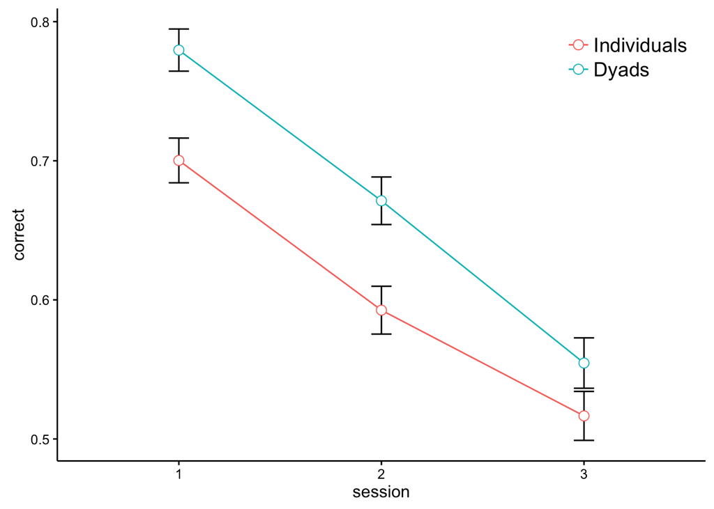

### Post-hoc tests

Given the interaction effects, we now do post-hoc testing to figure out what generates the interactions. The mixed effects model corresponds to an ANOVA

```
## R2m = 0.05, R2 = 0.20
## conditionDyads: β = 0.45, SE = 0.07, t-stat = 6.42, p = 1.35760995387855e-10
## session2: β = -0.50, SE = 0.15, t-stat = -3.26, p = 0.00109959103698587
## session3: β = -0.84, SE = 0.15, t-stat = -5.55, p = 2.85552077314703e-08
## conditionDyads:session2: β = -0.09, SE = 0.09, t-stat = -0.99, p = 0.321017180577206
## conditionDyads:session3: β = -0.27, SE = 0.09, t-stat = -2.93, p = 0.00333980551101314
```

### Bootstrapping estimates

```
##
## ORDINARY NONPARAMETRIC BOOTSTRAP
##
##
## Call:
## boot(data = Data$correct[Data$condition == "Dyads" & Data$test ==
##     0], statistic = boot.mean, R = 10000)
##
##
## Bootstrap Statistics :
##      original        bias    std. error
## t1* 0.6684722 -6.711111e-05 0.005549399
```

### The first model tests main effects

```
## R2m = 0.01, R2 = 0.40
## conditionDyads: β = 0.44, SE = 0.26, t-stat = 1.66, p = 0.0962022607586219
## session: β = -0.17, SE = 0.22, t-stat = -0.81, p = 0.42018078175256
```

### The second model tests interaction effects

```
## Data: Data[Data$test == 1, ]
## Models:
## model1: correct ~ condition + session + (1 + session | subject) + (1 +
## model1:     condition + session | stimulus)
## model2: correct ~ condition * session + (1 + session | subject) + (1 +
## model2:     condition + session | stimulus)
##        Df    AIC    BIC  logLik deviance  Chisq Chi Df Pr(>Chisq)
## model1 12 1499.0 1560.6 -737.51   1475.0
## model2 13 1497.1 1563.8 -735.55   1471.1 3.9352      1    0.04728 *
## ---
## Signif. codes:  0 '***' 0.001 '**' 0.01 '*' 0.05 '.' 0.1 ' ' 1
```

```
## R2m = 0.02, R2 = 0.40
## conditionDyads: β = -0.20, SE = 0.42, t-stat = -0.49, p = 0.626433835923232
## session: β = -0.32, SE = 0.23, t-stat = -1.38, p = 0.168420423284899
## conditionDyads:session: β = 0.33, SE = 0.16, t-stat = 2.01, p = 0.0448559079644786
```

### Plotting the best model (interaction effects)

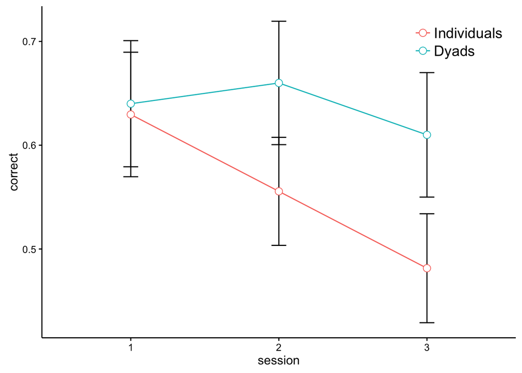

### Post-hoc testing

Given the interaction effects, we now do post-hoc testing to figure out what generates the interactions. The mixed effects model corresponds to an ANOVA

```
## R2m = 0.02, R2 = 0.47
## conditionDyads: β = 0.10, SE = 0.33, t-stat = 0.29, p = 0.771136850940554
## session2: β = -0.23, SE = 0.39, t-stat = -0.59, p = 0.556210619176346
## session3: β = -0.64, SE = 0.46, t-stat = -1.40, p = 0.162765527105495
## conditionDyads:session2: β = 0.52, SE = 0.33, t-stat = 1.59, p = 0.111932503118875
## conditionDyads:session3: β = 0.71, SE = 0.33, t-stat = 2.14, p = 0.0323760926111402
```

```
## R2m = 0.00, R2 = 1.00
## session2: β = 0.31, SE = 7.36, t-stat = 0.04, p = 0.966628786808726
## session3: β = 1.06, SE = 17.48, t-stat = 0.06, p = 0.951820791577848
```

```
## R2m = 0.00, R2 = 0.40
## session2: β = 0.14, SE = 0.45, t-stat = 0.32, p = 0.750466169126137
## session3: β = -0.18, SE = 0.40, t-stat = -0.44, p = 0.660498637597859
```

## Analysis 3

Extracting learning curve from each participant/dyad and predicting:

- condition (do dyads and participants have different learning curves?)

. also by first cycle only

- post-test performance (does learning curve reflect rule learning?)

### Prepare the data

### Predicting condition from learning curve

Main Effects first and Interaction second

```
## R2m = 0.20, R2 = 0.20
## intercept: β = 0.65, SE = 0.30, t-stat = 2.15, p = 0.031606487599284
## slope: β = 31.54, SE = 10.33, t-stat = 3.05, p = 0.00227510414717453
## session: β = 0.46, SE = 0.25, t-stat = 1.87, p = 0.0610080909378378
```

```
## R2m = 0.19, R2 = 0.19
## intercept: β = 0.61, SE = 0.72, t-stat = 0.85, p = 0.395209887722664
## slope: β = 26.01, SE = 22.53, t-stat = 1.15, p = 0.248416717377844
## session: β = 0.41, SE = 0.32, t-stat = 1.27, p = 0.202919314778466
## intercept:session: β = 0.02, SE = 0.36, t-stat = 0.06, p = 0.950759955003493
## slope:session: β = 3.29, SE = 12.18, t-stat = 0.27, p = 0.786917182643855
```

### Predicting condition from learning curve in first cycle

```
## R2m = 0.08, R2 = 0.08
## interceptC: β = 0.75, SE = 0.27, t-stat = 2.78, p = 0.00536307544314636
## slopeC: β = 10.52, SE = 4.18, t-stat = 2.52, p = 0.0118532371320624
## sessionC: β = 0.23, SE = 0.22, t-stat = 1.03, p = 0.301502596945371
```

```
## R2m = 0.08, R2 = 0.08
## interceptC: β = 0.79, SE = 0.66, t-stat = 1.20, p = 0.230795552278099
## slopeC: β = 10.87, SE = 9.40, t-stat = 1.16, p = 0.247809584716804
## sessionC: β = 0.22, SE = 0.24, t-stat = 0.93, p = 0.35360288981581
## interceptC:sessionC: β = -0.02, SE = 0.32, t-stat = -0.07, p = 0.947268493383661
## slopeC:sessionC: β = -0.20, SE = 4.92, t-stat = -0.04, p = 0.968366513397658
```

### Predicting test performance from learning curve

```
## R2m = 0.07, R2 = 0.21
## intercept: β = -0.10, SE = 0.07, t-stat = -1.42, p = 0.156541162711128
## slope: β = 2.36, SE = 1.06, t-stat = 2.22, p = 0.0261872233184851
## condition2: β = 0.16, SE = 0.11, t-stat = 1.43, p = 0.154153985385186
```

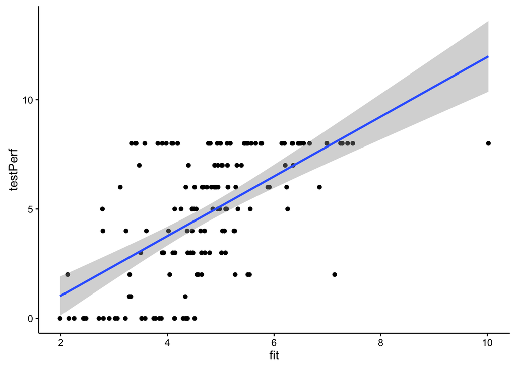

## Self-reported effort and motivation by condition

### Loading Data

```r
Data=read.csv('AlienSurvey.csv', sep=",", header=TRUE) # Name of the file

Data$Pair[Data$Condition=='Individuals']=Data$Pair[Data$Condition=='Individuals']+26
Data$Subject=(Data$Pair*10)+Data$Subject
Data$Pair=factor(Data$Pair)
Data$Subject=factor(Data$Subject)
Data$Condition=factor(Data$Condition)
```

### Contrasting effort and motivation in dyads and individuals

```r
model1=lmer(Response~Condition+(1|Pair),REML=F,Data[Data$Question==3,])
ModelDiagnostics(model1,linear=T)
```

```
## R2m = 0.00, R2 = 0.15
```

```r
by(Data$Response[Data$Question==3],Data$Condition[Data$Question==3],stat.desc)
```

```
## Data$Condition[Data$Question == 3]: Individual
##      nbr.val     nbr.null       nbr.na          min          max
##   27.0000000    0.0000000    0.0000000    2.0000000    6.0000000
##        range          sum       median         mean      SE.mean
##    4.0000000   88.0000000    3.0000000    3.2592593    0.2592593
## CI.mean.0.95          var      std.dev     coef.var
##    0.5329150    1.8148148    1.3471506    0.4133303
## --------------------------------------------------------
## Data$Condition[Data$Question == 3]: Pair
##      nbr.val     nbr.null       nbr.na          min          max
##   51.0000000    0.0000000    1.0000000    1.0000000    7.0000000
##        range          sum       median         mean      SE.mean
##    6.0000000  164.0000000    3.0000000    3.2156863    0.2365002
## CI.mean.0.95          var      std.dev     coef.var
##    0.4750246    2.8525490    1.6889491    0.5252220
```

```r
model2=lmer(Response~Condition+(1|Pair),REML=F,Data[Data$Question==4,])
ModelDiagnostics(model2,linear=T)
```

```
## R2m = 0.03, R2 = 0.03
```

```r
by(Data$Response[Data$Question==4],Data$Condition[Data$Question==4],stat.desc)
```

```
## Data$Condition[Data$Question == 4]: Individual
##      nbr.val     nbr.null       nbr.na          min          max
##   27.0000000    0.0000000    0.0000000    1.0000000    4.0000000
##        range          sum       median         mean      SE.mean
##    3.0000000   57.0000000    2.0000000    2.1111111    0.1715800
## CI.mean.0.95          var      std.dev     coef.var
##    0.3526877    0.7948718    0.8915558    0.4223159
## --------------------------------------------------------
## Data$Condition[Data$Question == 4]: Pair
##      nbr.val     nbr.null       nbr.na          min          max
##   51.0000000    0.0000000    1.0000000    1.0000000    6.0000000
##        range          sum       median         mean      SE.mean
##    5.0000000  130.0000000    2.0000000    2.5490196    0.1733493
## CI.mean.0.95          var      std.dev     coef.var
##    0.3481823    1.5325490    1.2379616    0.4856619
```